# Exercise 9.3

Lucia Camenisch

18 novembre 2022

Please note that this exercise follows the [errata](https://www.dataminingbook.com/content/errata-r-edition) version of the book.

First of all, we upload the necessary packages.

```r
library(data.table)   # data table, fread()
library(rpart)        # classification/regression trees
library(rpart.plot)   # plotting trees
library(knitr)        # r markdown
library(kableExtra)   # kable parameters
library(ggplot2)      # plotting
library(dplyr)        # bind_rows()
library(forecast)     # accuracy()
library(caret)        # confusionMatrix()


options(scipen = 999) # disable scientific notation
```

Then, we load our data and keep only the relevant variables for this exercise.

```r
ToyotaCorolla <- fread("ToyotaCorolla.csv") # importing data
# selecting columns cited in exercise
ToyotaCorolla <- ToyotaCorolla[, list(Price, Age_08_04, KM, Fuel_Type, HP, Automatic,
                                      Doors, Quarterly_Tax, Mfr_Guarantee,
                                      Guarantee_Period, Airco, Automatic_airco,
                                      CD_Player, Powered_Windows, Sport_Model, Tow_Bar)]
```

Please refer to exercise 6.4 for the data exploration phase.

We partition the data into training and validation sets.

```r
set.seed(111)  # set seed for reproducing the partition

# generating training set index
train.index <- sample(c(1:nrow(ToyotaCorolla)), 0.6*nrow(ToyotaCorolla))
# generating validation set index as the complementary of training set
valid.index <- setdiff(c(1:nrow(ToyotaCorolla)), train.index)

# creating data tables Train and Valid using the indexes
Train <- ToyotaCorolla[train.index, ]
Valid <- ToyotaCorolla[valid.index, ]

# removing indexes as they aren't used anymore
rm(train.index, valid.index)
```

# 1 Run a regression tree. Keep the minimum number of records in a terminal node to $1$, maximum number of tree levels to $30$, and $cp = 0.001$, to make the run least restrictive.

We run the regression tree using `rpart` and plot it with `prp`.

- The minimal number of records in a terminal node is set using `minbucket`;
- The maximum number of tree levels is set using `maxdepth`;
- The compexity parameter is set using `cp`.

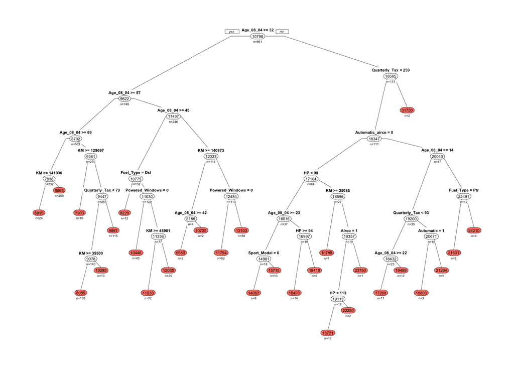

```r
# running the regression tree using the anova method on training data
Tree <- rpart(Price ~ . , data = Train, method = "anova", minbucket = 1, maxdepth = 30, cp = 0.001)

# plotting the tree
prp(Tree, type = 1,                                                 # labels all nodes
    extra = 1,                                                      # displays n = ...
    varlen = -16,                                                   # number of chars of variables
    under = TRUE,                                                   # n = ... appears under node
    digits = -1,                                                    # avoid scientific notation
    box.col=ifelse(Tree$frame$var == "<leaf>", '#FA8072', 'white')) # coloring leaves in pink
```

## 1.1 Which appear to be the three or four most important car specifications for predicting the car’s price?

From looking at the tree, `Age_08_04` clearly seems like the most important characteristic. It appears in eight different nodes. `KM` also seems to intervene a lot. `Quarterly_Tax` and `Automatic_Airco` also seem to be important as they are among the first nodes (closer to the root) in the regression tree.

However, our `Tree` object stores a measure of variable importance which we can examine to get a more precise idea.

```r
# kable to print importance as a pretty table
# kable_styling to control width of table
# we access the importance values by selecting Tree$variable.importance
kable_styling(kable(Tree$variable.importance, col.names = "Importance"), full_width = FALSE)
```

|  | Importance |
| --- | --- |
| Age_08_04 | 10035683169 |
| Automatic_airco | 3443961472 |
| KM | 2810834400 |
| Quarterly_Tax | 1813674625 |
| HP | 1041557179 |
| Guarantee_Period | 589111916 |
| CD_Player | 306517618 |
| Fuel_Type | 134827545 |
| Airco | 112739913 |
| Powered_Windows | 95030427 |
| Doors | 66222786 |
| Automatic | 30524073 |
| Sport_Model | 26879397 |
| Mfr_Guarantee | 24253854 |
| Tow_Bar | 15031662 |

We express these values as percentages by dividing by the sum of all importance values and multiplying by 100

```r
# kable and kable_styling as before
# we multiply by 100, divide by the sum and round the percentages to 2 decimals.
kable_styling(kable(round(100*Tree$variable.importance / sum(Tree$variable.importance), 2),
                    col.names = "Importance %"), full_width = FALSE)
```

|  | Importance % |
| --- | --- |
| Age_08_04 | 48.84 |
| Automatic_airco | 16.76 |
| KM | 13.68 |
| Quarterly_Tax | 8.83 |
| HP | 5.07 |
| Guarantee_Period | 2.87 |
| CD_Player | 1.49 |
| Fuel_Type | 0.66 |
| Airco | 0.55 |
| Powered_Windows | 0.46 |
| Doors | 0.32 |
| Automatic | 0.15 |
| Sport_Model | 0.13 |
| Mfr_Guarantee | 0.12 |
| Tow_Bar | 0.07 |

We can see that `Age_08_04` has an impact that is definitely superior to other variables, accounting for almost half of importance according to our tree. `Automatic_airco` and `KM` are the other two variables which have more than 10% of importance.

## 1.2 Compare the prediction errors of the training and validation sets by examining their RMS error and by plotting the two boxplots.

We construct two data tables called `TrainAccuracy` and `ValidAccuracy`. They will contain the `Price` column from `Train` and `Valid` respectively, the predicted prices for each set obtained using our `Tree` and the residuals obtained by subtracting the first two columns together.

```r
# creating the data table by taking the Price column from Train and
# using the predict() function to predict prices of Train with Tree
TrainAccuracy <- data.table("Values" = Train$Price, "PredictedValues" = predict(Tree, Train))
# adding Residuals column by subtracting Values - PredictedValues
TrainAccuracy <- TrainAccuracy[, Residuals := Values - PredictedValues]
# displaying the first rows of TrainAccuracy
head(TrainAccuracy)
```

```
##    Values PredictedValues  Residuals
## 1:  11950       11029.885   920.1154
## 2:   8745        8984.838  -239.8385
## 3:  21950       21631.250   318.7500
## 4:   7750        9896.696 -2146.6957
## 5:  10250        9896.696   353.3043
## 6:  22250       21294.444   955.5556
```

```r
# creating the data table by taking the Price column from Valid and
# using the predict() function to predict prices of Valid with Tree
ValidAccuracy <- data.table("Values" = Valid$Price, "PredictedValues" = predict(Tree, Valid))
# adding Residuals column by subtracting Values - PredictedValues
ValidAccuracy <- ValidAccuracy[, Residuals := Values - PredictedValues]
# displaying the first rows of ValidAccuracy
head(ValidAccuracy)
```

```
##    Values PredictedValues Residuals
## 1:  13950        14062.50 -112.5000
## 2:  12950        13102.59 -152.5862
## 3:  16900        15715.00 1185.0000
## 4:  18600        14062.50 4537.5000
## 5:  20950        21294.44 -344.4444
## 6:  22500        13102.59 9397.4138
```

To get an idea of our Residuals, we will plot the following:

- Boxplot of Residuals
- Histogram of Residuals
- Residuals versus Predicted Values Scatterplot
- Normal QQ Plot of Residuals

To be able to plot results for `Train` and `Valid` side by side, we will stack `TrainAccuracy` and `ValidAccuracy` one on top of the other and add a dummy variable which indicates if the row belongs to `Train` or `Valid`. This new data table will be called `Accuracies`.

Organizing our data this way will allow us to use `facet_wrap()` from `ggplot2`.

```r
# bind_rows from dplyr packages allows to stack the two tables together
# we add a new column called Set which takes the value "Train" or "Valid"
Accuracies = bind_rows(TrainAccuracy[, Set := "Train"], ValidAccuracy[, Set := "Valid"])
# displaying head and tail off Accuracies
head(Accuracies)
```

```
##    Values PredictedValues  Residuals   Set
## 1:  11950       11029.885   920.1154 Train
## 2:   8745        8984.838  -239.8385 Train
## 3:  21950       21631.250   318.7500 Train
## 4:   7750        9896.696 -2146.6957 Train
## 5:  10250        9896.696   353.3043 Train
## 6:  22250       21294.444   955.5556 Train
```

```r
tail(Accuracies)
```

```
##    Values PredictedValues  Residuals   Set
## 1:   7950        8064.539  -114.5388 Valid
## 2:   7750        8064.539  -314.5388 Valid
## 3:   7950        8064.539  -114.5388 Valid
## 4:   8450        8064.539   385.4612 Valid
## 5:   8450        8064.539   385.4612 Valid
## 6:   6950        8064.539 -1114.5388 Valid
```

We can now plot!

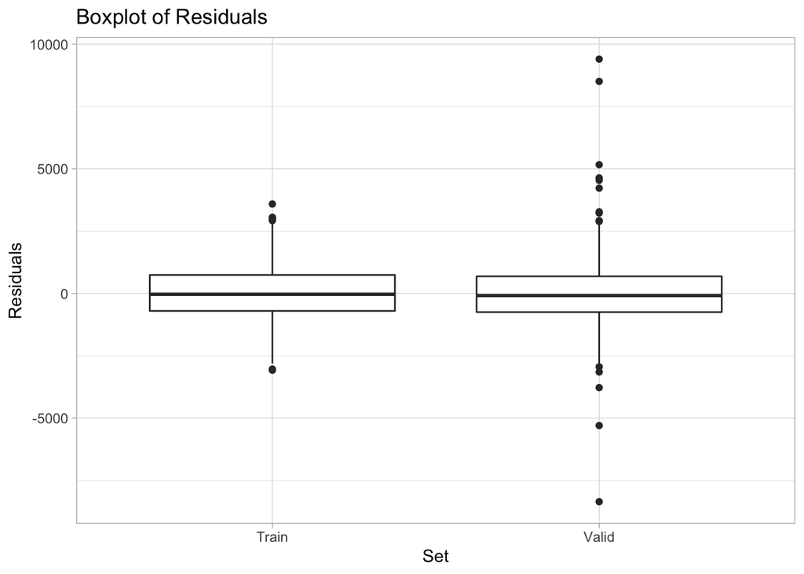

```r
ggplot(data = Accuracies, aes(x = Set, y = Residuals)) + # plotting residuals
  geom_boxplot() +                                       # making boxplot
  theme_light() +                                        # changing aesthetic theme
  labs(y = "Residuals", title = "Boxplot of Residuals")  # writing labels
```

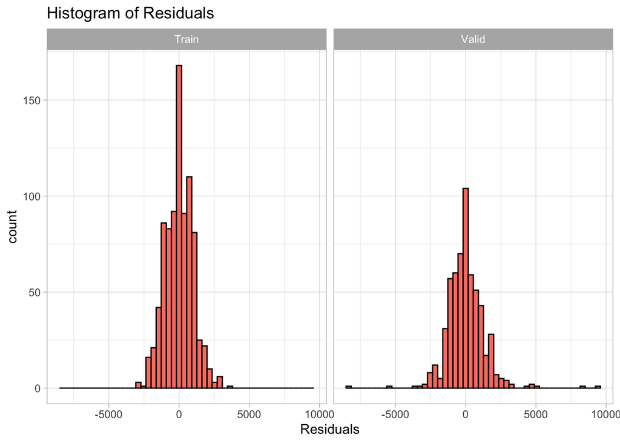

```r
# same as previous plot but using geom_histogram to draw the histogram
# facet_wrap in all the following plots allows to draw one plot for Train and one for Valid
ggplot(data = Accuracies, aes(Residuals)) +
  facet_wrap(~Set) +
  geom_histogram(color = "black", fill = "#FA8072", bins = 50) +
  theme_light() +
  labs(title = "Histogram of Residuals")
```

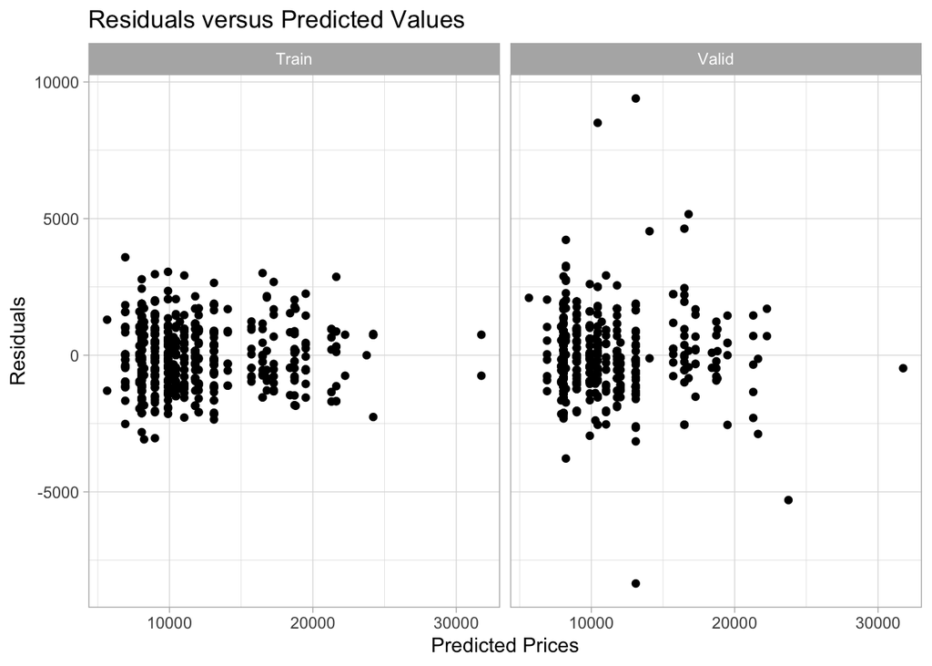

```r
# same as previous plot but using geom_point to draw points on the plot
ggplot(data = Accuracies, aes(x = PredictedValues, y = Residuals)) +
  facet_wrap(~Set) +
  geom_point() +
  theme_light() +
  labs(x = "Predicted Prices", y = "Residuals", title = "Residuals versus Predicted Values")
```

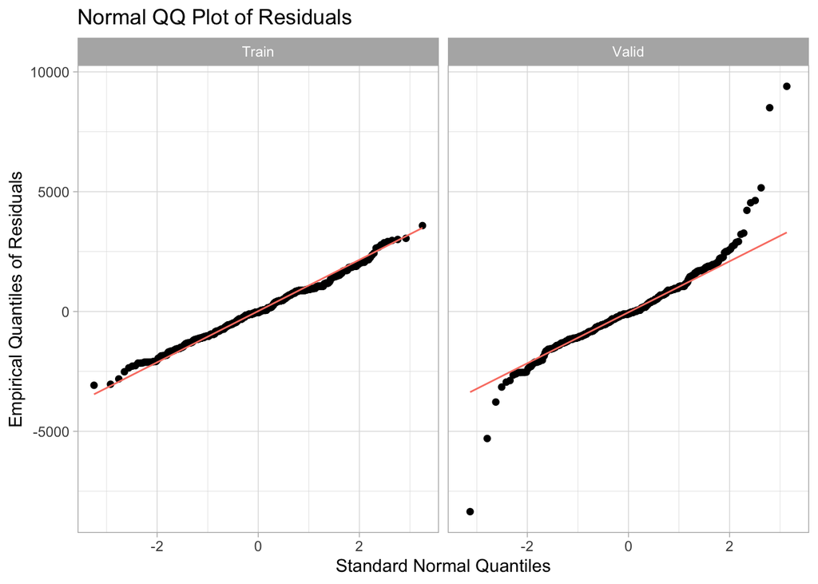

```r
# same as previous plot but using geom_qq to draw residuals points on the plot and
# geom_qq_line to draw the straight line
ggplot(data = Accuracies, aes(sample = Residuals)) +
  facet_wrap(~Set) +
  geom_qq() +
  geom_qq_line(color = "#FA8072") +
  theme_light() +
  labs(x = "Standard Normal Quantiles", y = "Empirical Quantiles of Residuals",
       title = "Normal QQ Plot of Residuals")
```

The boxplots clearly show that `Valid` has more extreme values than `Train`. The median and quartiles are almost identical, but `Valid` has more outliers.

The histograms reaffirm this and also show that `Train` has a lot more residuals which are very close to zero.

The scatterplot of residuals versus fitted values still shows that `Valid` has bigger outliers, but we can see that these outliers are situated a bit everywhere with respect to fitted values, indicating that there isn’t a special subset of fitted values (for example high or low prices) which has outlier problems.

The normal QQ plots clearly show that the `Train` residuals are normally distributed, whereas the `Valid` residuals tend to stray away from a normal distribution.

These four different plots all show us that the regression tree clearly performs better on training data and may even be overfitting the training data, as it is one of the common problems with trees. We should find ways to solve this overfitting problem.

We will look at the five accuracy measures introduced in exercise 6.4 for `Train` and `Valid`.

```r
AccTrain = accuracy(TrainAccuracy$PredictedValues, TrainAccuracy$Values)
AccValid = accuracy(ValidAccuracy$PredictedValues, ValidAccuracy$Values)
AccTrain
```

```
##                              ME     RMSE      MAE       MPE     MAPE
## Test set -0.0000000000001130983 984.8101 777.8541 -1.053649 7.907828
```

```r
AccValid
```

```
##               ME     RMSE      MAE      MPE    MAPE
## Test set 4.38371 1324.695 911.8358 -1.55116 9.20991
```

`Train` has practically no Mean Error, the value is very close to zero. Such a result indicates that overfitting is probably going on. The Mean Error for `Valid` is also small, but more “realistic”. We can note that compared to the linear regression in exercise 6.4, the ME are much smaller than before!

The other measure changing significantly is the Root Mean Squared Error. While the RMSE of `Train` is around 1000, the one for `Valid` is around 1300. This shows that variation in the `Valid` set is much higher. For the linear regression, we had RMSE values around `1200`, so the regression tree has a bigger variation when predicting new data.

MAE is also smaller for `Train` (778 vs 912). MPE and MAPE are quite close for both sets. The values for these three measures in `Valid` are quite similar to the ones from the linear regression.

## 1.3 How might we achieve better validation predictive performance at the expense of training performance?

The predictive performance can be improved by pruning our tree. This will help to avoid overfitting. We will choose the best-pruned tree by looking at the CP table and identifying the minimal cross-validation error. We will add the associated standard error to the cross-validation error and choose the tree with least nodes which has a cross-validation error under the computed value.

```r
# printing the cptable of our Tree with printcp()
CPTable = printcp(Tree)
```

```
##
## Regression tree:
## rpart(formula = Price ~ ., data = Train, method = "anova", minbucket = 1,
##     maxdepth = 30, cp = 0.001)
##
## Variables actually used in tree construction:
##  [1] Age_08_04       Airco           Automatic       Automatic_airco
##  [5] Fuel_Type       HP              KM              Powered_Windows
##  [9] Quarterly_Tax   Sport_Model
##
## Root node error: 11834855693/861 = 13745477
##
## n= 861
##
##           CP nsplit rel error  xerror     xstd
```

[output cut: 27 more lines]

We see that the last row (27) has the minimal cross-validation error.

```r
CPTable[27, 4]                # minimal cross-validation error
```

```
## [1] 0.1291137
```

```r
CPTable[27, 5]                # associated standard-error
```

```
## [1] 0.01229899
```

```r
CPTable[27, 4]+CPTable[27, 5] # we add the two values together
```

```
## [1] 0.1414127
```

This means that we can choose the tree with the fewest nodes which has a cross-validation error smaller than 0.1414127.

This tree corresponds to row 16 in `CPTable`.

We retrieve the CP value of row 16 and prune our `Tree` using our new CP.

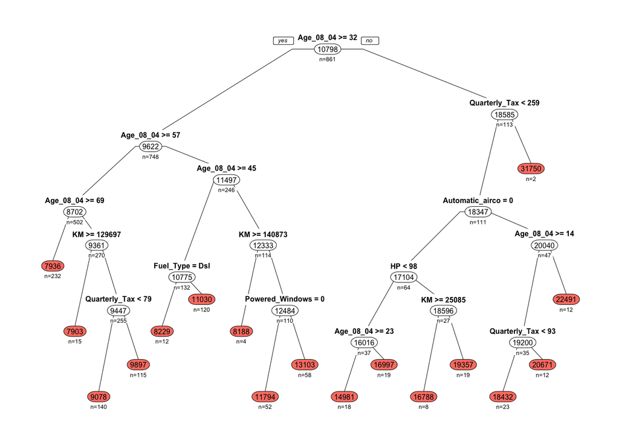

```r
CPBestPruned = CPTable[16, 1] # retrieving the CP for the Best Pruned Tree
# pruning our tree with prune(), using the CP from above
BestPrunedTree = prune(Tree, CPBestPruned)
# plotting BestPrunedTree with same parameters as before
prp(BestPrunedTree, type = 1, extra = 1, varlen = -16, under = TRUE, digits = -1,
    box.col=ifelse(BestPrunedTree$frame$var == "<leaf>", '#FA8072', 'white'))
```

Our `BestPrunedTree` has 17 leaves. We have identified which branches where pruned from our original `Tree` as can be seen in this diagram:

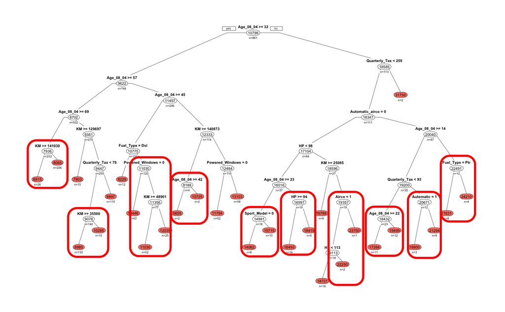

Branches inside red boxes were reduced to leaves when pruning to obtain the Best Pruned Tree.

We go through the same steps as before to create `AccuraciesBP` in order to display our residual analysis plots and compute accuracies measures.

```r
# creating the data table by taking the Price column from Train and
# using the predict() function to predict prices of Train with BestPrunedTree
TrainAccuracy <- data.table("Values" = Train$Price, "PredictedValues" = predict(BestPrunedTree, Train))
# adding Residuals column by subtracting Values - PredictedValues
TrainAccuracy <- TrainAccuracy[, Residuals := Values - PredictedValues]

# creating the data table by taking the Price column from Valid and
# using the predict() function to predict prices of Valid with BestPrunedTree
ValidAccuracy <- data.table("Values" = Valid$Price, "PredictedValues" = predict(BestPrunedTree, Valid))
# adding Residuals column by subtracting Values - PredictedValues
ValidAccuracy <- ValidAccuracy[, Residuals := Values - PredictedValues]

# bind_rows from dplyr packages allows to stack the two tables together
# we add a new column called Set which takes the value "Train" or "Valid"
AccuraciesBP = bind_rows(TrainAccuracy[, Set := "Train"], ValidAccuracy[, Set := "Valid"])
```

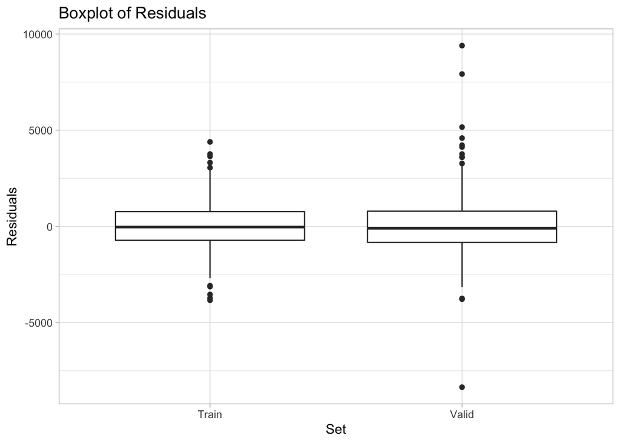

```r
ggplot(data = AccuraciesBP, aes(x = Set, y = Residuals)) + # plotting residuals
  geom_boxplot() +                                         # making boxplot
  theme_light() +                                          # changing aesthetic theme
  labs(y = "Residuals", title = "Boxplot of Residuals")    # writing labels
```

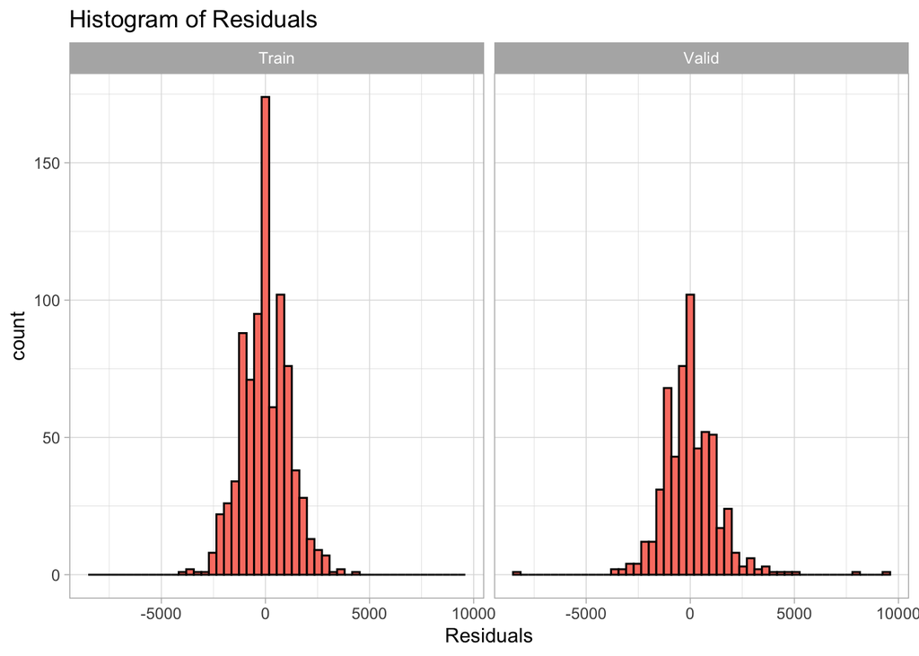

```r
# same as previous plot but using geom_histogram to draw the histogram
# facet_wrap in all the following plots allows to draw one plot for Train and one for Valid
ggplot(data = AccuraciesBP, aes(Residuals)) +
  facet_wrap(~Set) +
  geom_histogram(color = "black", fill = "#FA8072", bins = 50) +
  theme_light() +
  labs(title = "Histogram of Residuals")
```

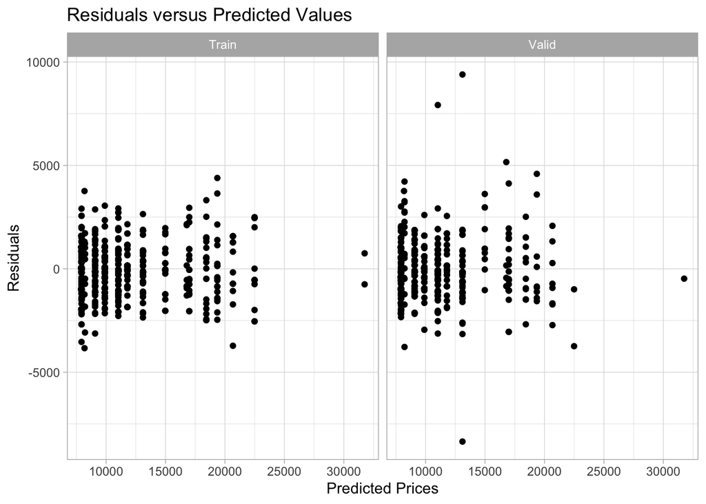

```r
# same as previous plot but using geom_point to draw points on the plot
ggplot(data = AccuraciesBP, aes(x = PredictedValues, y = Residuals)) +
  facet_wrap(~Set) +
  geom_point() +
  theme_light() +
  labs(x = "Predicted Prices", y = "Residuals", title = "Residuals versus Predicted Values")
```

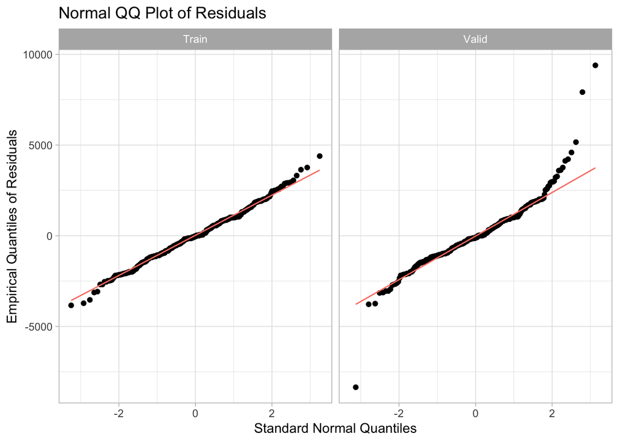

```r
# same as previous plot but using geom_qq to draw residuals points on the plot and
# geom_qq_line to draw the straight line
ggplot(data = AccuraciesBP, aes(sample = Residuals)) +
  facet_wrap(~Set) +
  geom_qq() +
  geom_qq_line(color = "#FA8072") +
  theme_light() +
  labs(x = "Standard Normal Quantiles", y = "Empirical Quantiles of Residuals",
       title = "Normal QQ Plot of Residuals")
```

We notice that overall, there isn’t much change. The performance is still much better on our training data. There is a slight improvement in `Valid`, we see that there are three residual outliers (one negative and two positives) which are still very big, but all other outliers have been mitigated a bit in confront to the `Valid` distributions for `Tree`.

We compute the new accuracy measures for `BestPrunedTree` and display them alongside the accuracy measures from before:

```r
AccTrainBP = accuracy(TrainAccuracy$PredictedValues, TrainAccuracy$Values)
AccValidBP = accuracy(ValidAccuracy$PredictedValues, ValidAccuracy$Values)

AccTrain
```

```
##                              ME     RMSE      MAE       MPE     MAPE
## Test set -0.0000000000001130983 984.8101 777.8541 -1.053649 7.907828
```

```r
AccTrainBP
```

```
##                              ME     RMSE     MAE       MPE     MAPE
## Test set -0.0000000000001108571 1117.592 863.377 -1.279724 8.658337
```

```r
AccValid
```

```
##               ME     RMSE      MAE      MPE    MAPE
## Test set 4.38371 1324.695 911.8358 -1.55116 9.20991
```

```r
AccValidBP
```

```
##                ME     RMSE      MAE       MPE     MAPE
## Test set 4.847265 1351.445 948.0232 -1.542561 9.404007
```

The performance on the training set has become a bit less accurate (excepted ME, all other four measures have increased in absolute value).

The performance for the validation set has also slightly worsened if we look at ME, RMSE and MAE. However, this variation is very small and we could argue that since the overall accuracy measures are very similar, keeping the best-pruned tree would be best according to the principle of model parsimony.

Despite pruning the tree, overfitting problems seem to persist.

## 1.4 Create a less deep tree by leaving the arguments `cp`, `minbucket`, and `maxdepth` at their defaults. Compared to the deeper tree, what is the predictive performance on the validation set?

Let us create a tree with parameters set to their default.

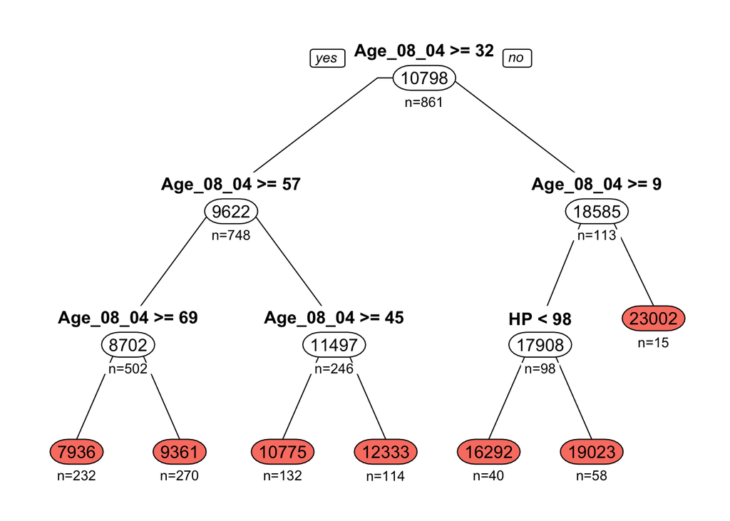

```r
# running the regression tree using the anova method on training data
DefaultTree <- rpart(Price ~ . , data = Train, method = "anova")

# plotting the tree with the same parameters as before
prp(DefaultTree, type = 1, extra = 1, varlen = -16, under = TRUE, digits = -1,
    box.col=ifelse(DefaultTree$frame$var == "<leaf>", '#FA8072', 'white'))
```

We can see that the number of nodes is much smaller than with our previous trees!

Again, we create `AccuraciesDef` to display our residual analysis plots and compute the accuracy measures.

```r
# creating the data table by taking the Price column from Train and
# using the predict() function to predict prices of Train with DefaultTree
TrainAccuracy <- data.table("Values" = Train$Price, "PredictedValues" = predict(DefaultTree, Train))
# adding Residuals column by subtracting Values - PredictedValues
TrainAccuracy <- TrainAccuracy[, Residuals := Values - PredictedValues]

# creating the data table by taking the Price column from Valid and
# using the predict() function to predict prices of Valid with DefaultTree
ValidAccuracy <- data.table("Values" = Valid$Price, "PredictedValues" = predict(DefaultTree, Valid))
# adding Residuals column by subtracting Values - PredictedValues
ValidAccuracy <- ValidAccuracy[, Residuals := Values - PredictedValues]

# bind_rows from dplyr packages allows to stack the two tables together
# we add a new column called Set which takes the value "Train" or "Valid"
AccuraciesDef = bind_rows(TrainAccuracy[, Set := "Train"], ValidAccuracy[, Set := "Valid"])
```

We display the four plots:

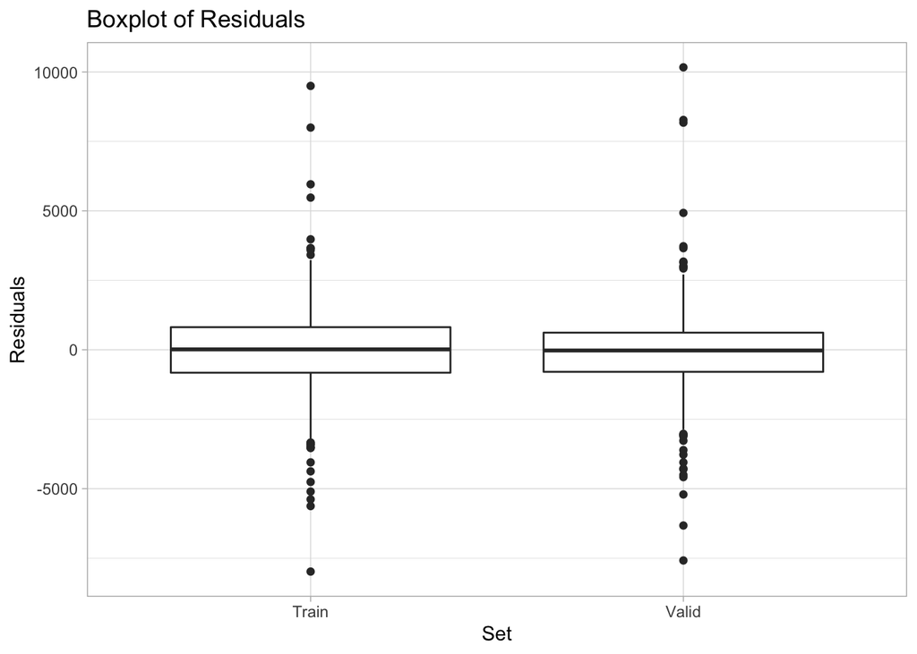

```r
ggplot(data = AccuraciesDef, aes(x = Set, y = Residuals)) + # plotting residuals
  geom_boxplot() +                                          # making boxplot
  theme_light() +                                           # changing aesthetic theme
  labs(y = "Residuals", title = "Boxplot of Residuals")     # writing labels
```

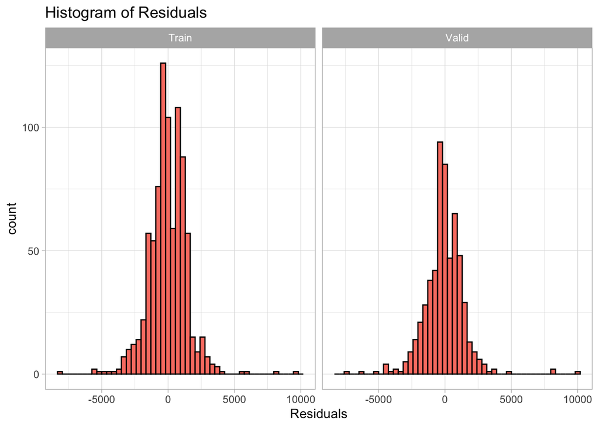

```r
# same as previous plot but using geom_histogram to draw the histogram
# facet_wrap in all the following plots allows to draw one plot for Train and one for Valid
ggplot(data = AccuraciesDef, aes(Residuals)) +
  facet_wrap(~Set) +
  geom_histogram(color = "black", fill = "#FA8072", bins = 50) +
  theme_light() +
  labs(title = "Histogram of Residuals")
```

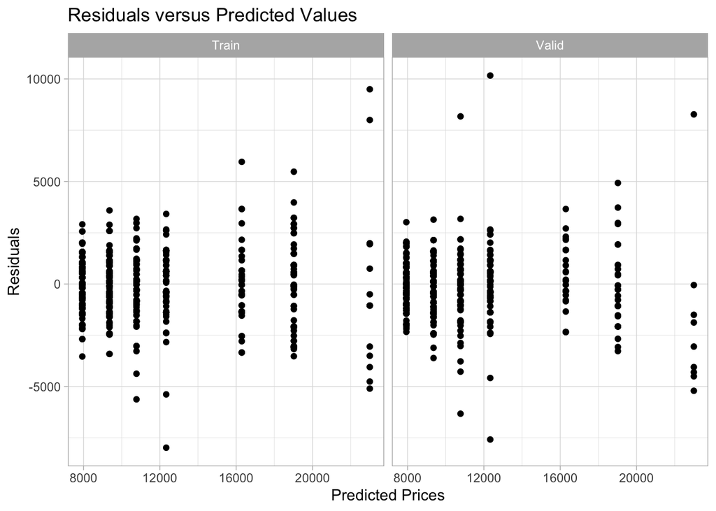

```r
# same as previous plot but using geom_point to draw points on the plot
ggplot(data = AccuraciesDef, aes(x = PredictedValues, y = Residuals)) +
  facet_wrap(~Set) +
  geom_point() +
  theme_light() +
  labs(x = "Predicted Prices", y = "Residuals", title = "Residuals versus Predicted Values")
```

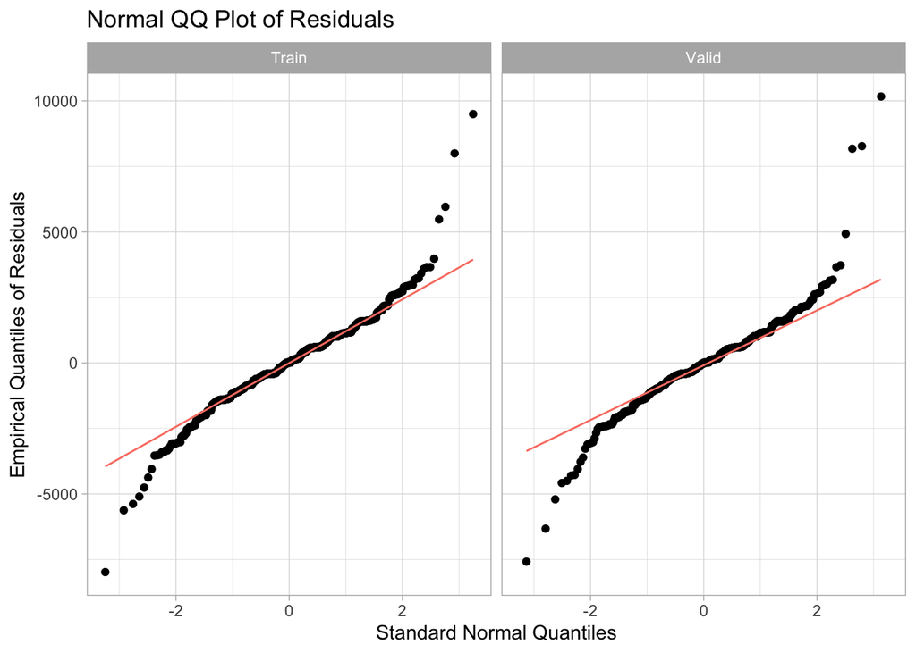

```r
# same as previous plot but using geom_qq to draw residuals points on the plot and
# geom_qq_line to draw the straight line
ggplot(data = AccuraciesDef, aes(sample = Residuals)) +
  facet_wrap(~Set) +
  geom_qq() +
  geom_qq_line(color = "#FA8072") +
  theme_light() +
  labs(x = "Standard Normal Quantiles", y = "Empirical Quantiles of Residuals",
       title = "Normal QQ Plot of Residuals")
```

Clearly, the overfitting problem isn’t present anymore! The tree seems to perform in a similar way for `Train` and `Valid`. However, we can see from all four plots that the predictions don’t seem more accurate than before. We still have similar extreme residuals.

We compute the accuracy measures to compare our trees’ performances.

```r
AccTrainDef = accuracy(TrainAccuracy$PredictedValues, TrainAccuracy$Values)
AccValidDef = accuracy(ValidAccuracy$PredictedValues, ValidAccuracy$Values)

AccTrain
```

```
##                              ME     RMSE      MAE       MPE     MAPE
## Test set -0.0000000000001130983 984.8101 777.8541 -1.053649 7.907828
```

```r
AccTrainBP
```

```
##                              ME     RMSE     MAE       MPE     MAPE
## Test set -0.0000000000001108571 1117.592 863.377 -1.279724 8.658337
```

```r
AccTrainDef
```

```
##                             ME     RMSE      MAE      MPE     MAPE
## Test set 0.0000000000001563524 1422.662 1039.425 -1.76658 10.20945
```

```r
AccValid
```

```
##               ME     RMSE      MAE      MPE    MAPE
## Test set 4.38371 1324.695 911.8358 -1.55116 9.20991
```

```r
AccValidBP
```

```
##                ME     RMSE      MAE       MPE     MAPE
## Test set 4.847265 1351.445 948.0232 -1.542561 9.404007
```

```r
AccValidDef
```

```
##                 ME     RMSE      MAE       MPE     MAPE
## Test set -54.43018 1490.713 1026.991 -2.398268 10.26396
```

Except for ME, `AccTrainDef` and `AccValidDef` have now similar measures, which indicates that overfitting isn’t present anymore.

It looks like the ME on the training set will remain very small, this may be a general property of trees?

Overall, the accuracy measures of `AccTrainDef` and `AccValidDef` are worse than for the previous two trees. Solving the overfitting problem hasn’t brought an improvement in predictive performance. In this situation, I would choose to use the best-pruned tree, which has a better predictive performance and is a simpler model than the first full tree.

# 2 Let us see the effect of turning the price variable into a categorical variable.

We bin our `Price` variable. We turn it into a factor with 20 price levels and we display the levels below.

```r
# creating a factor with 20 levels by using the function cut() on Price
ToyotaCorolla[, Price := cut(Price, breaks = 20,         # cutting into 20 bins
                             dig.lab = 5,                # number of digits for levels display
                             include.lowest = TRUE)]     # lowest value included in 1st level

# we create a table with the intervals/levels and numbers from 1 to 20
PriceLevels = as.data.table(levels(ToyotaCorolla$Price)) # creating with levels
PriceLevels = PriceLevels[, Number := c(1:20)]           # adding numbers
PriceLevels = PriceLevels[, list(Number, V1)]            # reordering columns
# displaying PriceLevels as a table with same params as before + align for column alignment
kable_styling(kable(PriceLevels, col.names = c("Number", "Price Level"), align = "r"),
              full_width = FALSE)
```

| Number | Price Level |
| --- | --- |
| 1 | [4321.9,5757.5] |
| 2 | (5757.5,7165] |
| 3 | (7165,8572.5] |
| 4 | (8572.5,9980] |
| 5 | (9980,11388] |
| 6 | (11388,12795] |
| 7 | (12795,14202] |
| 8 | (14202,15610] |
| 9 | (15610,17018] |
| 10 | (17018,18425] |
| 11 | (18425,19832] |
| 12 | (19832,21240] |
| 13 | (21240,22648] |
| 14 | (22648,24055] |
| 15 | (24055,25462] |
| 16 | (25462,26870] |
| 17 | (26870,28278] |
| 18 | (28278,29685] |
| 19 | (29685,31092] |
| 20 | (31092,32528] |

```r
# renaming the Price column to Binned_Price
colnames(ToyotaCorolla)[1] = "Binned_Price"
```

For simplicity of display, we rename each level by its number and then plot the distribution of `Binned_Price`.

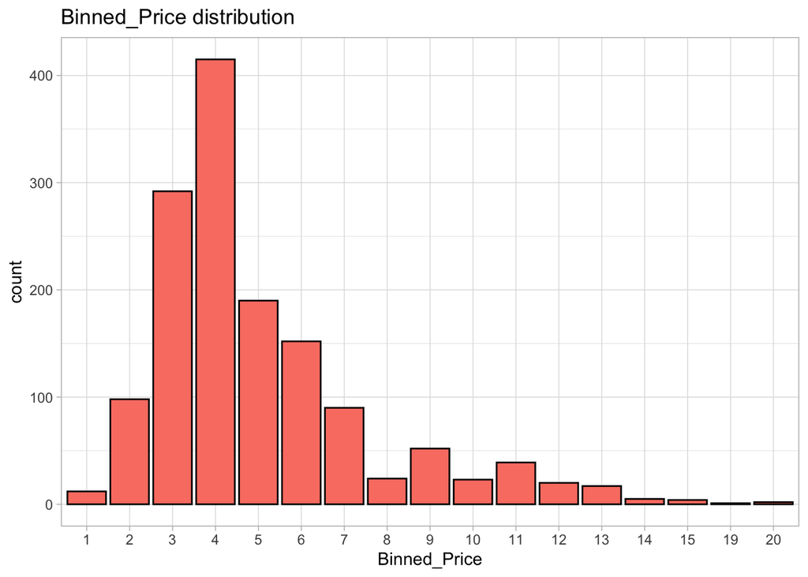

```r
# renaming levels with numbers from 1 to 20
levels(ToyotaCorolla$Binned_Price) = c(1:20)
# plotting with same parameters as before, using geom_bar
ggplot(ToyotaCorolla, aes(Binned_Price)) +
  geom_bar(color = "black", fill = "#FA8072") +
  theme_light() +
  labs(title = "Binned_Price distribution")
```

We can note from the distribution that no price belongs to level 16, 17 or 18!

Now, we repartition our data into `Train` and `Valid` in the same way as before.

```r
set.seed(111)  # set seed for reproducing the partition
# generating training set index
train.index <- sample(c(1:nrow(ToyotaCorolla)), 0.6*nrow(ToyotaCorolla))
# generating validation set index as the complementary of training set
valid.index <- setdiff(c(1:nrow(ToyotaCorolla)), train.index)

# creating data tables Train and Valid using the indexes
Train <- ToyotaCorolla[train.index, ]
Valid <- ToyotaCorolla[valid.index, ]

# removing indexes as they aren't used anymore
rm(train.index, valid.index)
```

We run a classification tree (`method = "class"`) with all parameters left as default and plot the tree.

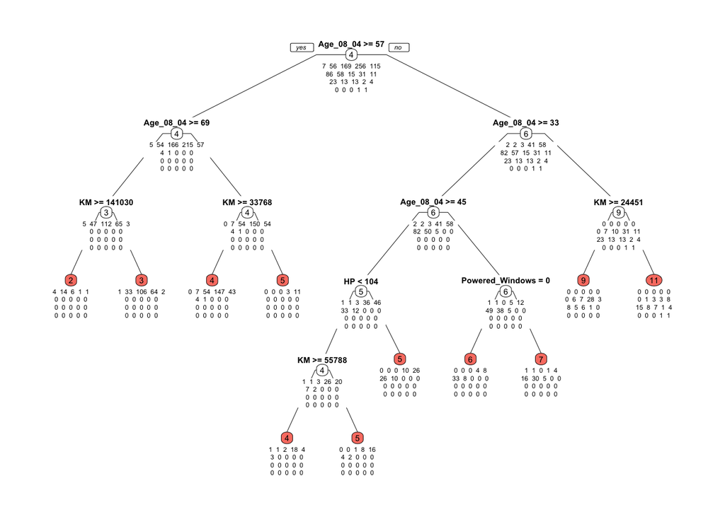

```r
# running the regression tree using the anova method on training data
ClassTree <- rpart(Binned_Price ~ . , data = Train, method = "class")

# plotting the tree with the same parameters as before
prp(ClassTree, type = 1, extra = 1, varlen = -16, under = TRUE, digits = -1,
    box.col=ifelse(ClassTree$frame$var == "<leaf>", '#FA8072', 'white'))
```

We can note that out of our 20 price classes, only classes 2, 3, 4, 5, 6, 7, 9 and 11 are represented. These classes coincide with the eight most represented classes in our `Binned_Price` distribution plot. This means that all prices estimated using this tree will be attributed to eight classes only, which all together represent the price interval

$$[5757.5, 14202] \cup (15610,17018] \cup
(18425,19832]$$

In other words, any price outside these intervals will be misclassified by `ClassTree`!

We can look at how many entries in our total `ToyotaCorolla` data fall outside of the classes present among the tree leaves.

```r
# computing number of rows which belong to classes that aren't outputs of ClassTree
nrow(ToyotaCorolla[Binned_Price %in% c(1, 8, 10, 12:20),])
```

```
## [1] 108
```

This means that at least 108 entries in our total data will be misclassified by `ClassTree`. Fortunately, this number isn’t too big compared to the total of 1436 records.

## 2.1 Compare the tree generated by the CT with the default one generated by the RT. Are they different? (Look at structure, the top predictors, size of tree, etc.) Why?

We plot the default tree again to be able to compare differences easily.

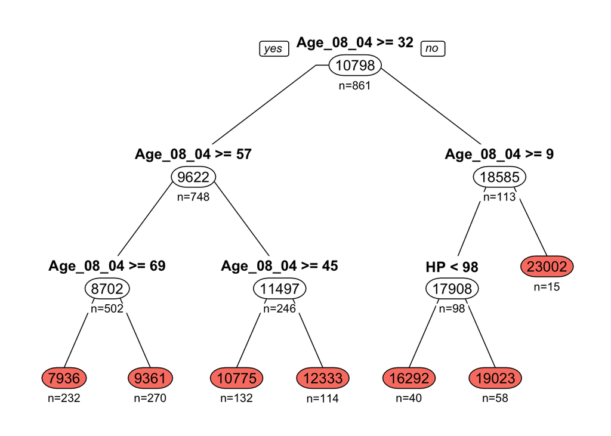

```r
# plotting the tree with the same parameters as before
prp(DefaultTree, type = 1, extra = 1, varlen = -16, under = TRUE, digits = -1,
    box.col=ifelse(DefaultTree$frame$var == "<leaf>", '#FA8072', 'white'))
```

As we said, the number of leaves is bigger with `ClassTree`. We see that `Age_08_04` still is the main criteria to classify prices.

`DefaultTree` only makes decisions based on age except for one node with `HP`. `ClassTree` on the other hand relies on `KM` as its secondary decision variable and has one node with `HP` and one node with `Powered_Windows`.

The interesting fact is that the splitting values for `Age_08_04` are similar in both trees. `DefaultTree` has 5 decision nodes for age and `ClassTree` has 4. The node not maintained in `ClassTree` is `Age_08_04 >= 9`.

We see that some structure of `DefaultTree` is preserved, but there are changes. To understand them better, we display a diagram of changes made to `DefaultTree` to give it a similar structure to `ClassTree`.

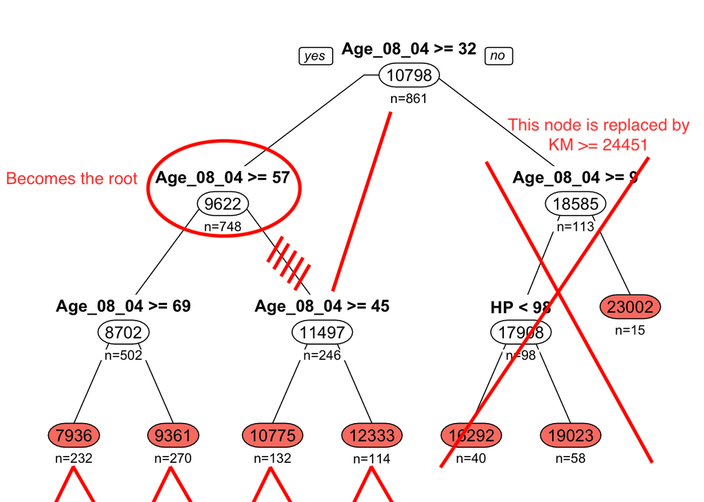

Modifying `DefaultTree` to get the general structure of `ClassTree`.

By changing the root and reassigning one edge, we can see the skeleton of `ClassTree` emerging!

Generally, `ClassTree` has a more complex structure and my hypothesis would be that it is linked to the high number of bins (20) that we have chosen. Since there are many classes, the structure is more complex than if we binned more roughly.

## 2.2 Predict the price, using the default RT and the CT, of a used Toyota Corolla with the specifications listed in Table 9.6.

We create `NewToyota`, a data table which contains the characteristics of the car listed in Table 9.6.

```r
# creating the data table
NewToyota = data.table(Age_08_04 = 77,
                       KM = 117000,
                       Fuel_Type = "Petrol",
                       HP = 110,
                       Automatic = 0,
                       Doors = 5,
                       Quarterly_Tax = 100,
                       Mfr_Guarantee = 0,
                       Guarantee_Period = 3,
                       Airco = 1,
                       Automatic_airco = 0,
                       CD_Player = 0,
                       Powered_Windows = 0,
                       Sport_Model = 0,
                       Tow_Bar = 1)
```

We predict the price of `NewToyota` with `DefaultTree` and `ClassTree`, using the `predict()` function to do so.

```r
# predicting approx price with default tree
predict(DefaultTree, NewToyota)
```

```
##        1
## 7935.711
```

```r
# predicting price classes with class tree
predict(ClassTree, NewToyota, type = "class")
```

```
## 1
## 3
## Levels: 1 2 3 4 5 6 7 8 9 10 11 12 13 14 15 16 17 18 19 20
```

The estimated price with `DefaultTree` is of $7936€$ approximately.

The attributed class with `ClassTree` is $(7165, 8572.5]$.

The estimated price being inside the price class shows that the two trees haven’t given disparate results. This is reassuring.

## 2.3 Compare the predictions in terms of the predictors that were used, the magnitude of the difference between the two predictions, and the advantages and disadvantages of the two methods.

For `DefaultTree`, the only predictor used was `Age_08_04`. We can follow the path and `NewToyota` will drop down into the leftmost leaf.

Fore `ClassTree`, `Age_08_04` and `KM` were used. `NewToyota` arrives into the second leftmost leaf of the tree.

The estimated price with `DefaultTree` falls close to the middle point of the `ClassTree` interval.

In order to compare the two methods, we want to evaluate the performance of `ClassTree` on our `Train` and `Valid` data. We compute the confusion matrices using the `confusionMatrix` from the `caret` package to do so.

We can already anticipate that each row corresponding to levels 1, 8, 10 and 12 to 20 will be full of zeros, as those levels aren’t part of the output classes of `ClassTree`.

```r
# computing predictions for Train and Valid
PredictTrain = predict(ClassTree, Train, type = "class")
PredictValid = predict(ClassTree, Valid, type = "class")

# computing confusion matrices for Train and Valid
confusionMatrix(PredictTrain, Train$Binned_Price)
```

```
## Confusion Matrix and Statistics
##
##           Reference
## Prediction   1   2   3   4   5   6   7   8   9  10  11  12  13  14  15  16  17
##         1    0   0   0   0   0   0   0   0   0   0   0   0   0   0   0   0   0
##         2    4  14   6   1   1   0   0   0   0   0   0   0   0   0   0   0   0
##         3    1  33 106  64   2   0   0   0   0   0   0   0   0   0   0   0   0
##         4    1   8  56 165  47   7   1   0   0   0   0   0   0   0   0   0   0
##         5    0   0   1  21  53  30  12   0   0   0   0   0   0   0   0   0   0
##         6    0   0   0   4   8  33   8   0   0   0   0   0   0   0   0   0   0
##         7    1   1   0   1   4  16  30   5   0   0   0   0   0   0   0   0   0
##         8    0   0   0   0   0   0   0   0   0   0   0   0   0   0   0   0   0
##         9    0   0   0   0   0   0   6   7  28   3   8   5   6   1   0   0   0
##         10   0   0   0   0   0   0   0   0   0   0   0   0   0   0   0   0   0
##         11   0   0   0   0   0   0   1   3   3   8  15   8   7   1   4   0   0
##         12   0   0   0   0   0   0   0   0   0   0   0   0   0   0   0   0   0
##         13   0   0   0   0   0   0   0   0   0   0   0   0   0   0   0   0   0
##         14   0   0   0   0   0   0   0   0   0   0   0   0   0   0   0   0   0
##         15   0   0   0   0   0   0   0   0   0   0   0   0   0   0   0   0   0
##         16   0   0   0   0   0   0   0   0   0   0   0   0   0   0   0   0   0
##         17   0   0   0   0   0   0   0   0   0   0   0   0   0   0   0   0   0
##         18   0   0   0   0   0   0   0   0   0   0   0   0   0   0   0   0   0
##         19   0   0   0   0   0   0   0   0   0   0   0   0   0   0   0   0   0
##         20   0   0   0   0   0   0   0   0   0   0   0   0   0   0   0   0   0
##           Reference
## Prediction  18  19  20
##         1    0   0   0
##         2    0   0   0
##         3    0   0   0
##         4    0   0   0
##         5    0   0   0
##         6    0   0   0
##         7    0   0   0
##         8    0   0   0
##         9    0   0   0
##         10   0   0   0
##         11   0   1   1
##         12   0   0   0
##         13   0   0   0
##         14   0   0   0
```

[output cut: 41 more lines]

```
## Pos Pred Value             NaN       NaN       NaN        NA        NA
## Neg Pred Value          0.9849  0.997677  0.995354        NA        NA
## Prevalence              0.0151  0.002323  0.004646         0         0
## Detection Rate          0.0000  0.000000  0.000000         0         0
## Detection Prevalence    0.0000  0.000000  0.000000         0         0
## Balanced Accuracy       0.5000  0.500000  0.500000        NA        NA
##                      Class: 18 Class: 19 Class: 20
## Sensitivity                 NA  0.000000  0.000000
## Specificity                  1  1.000000  1.000000
## Pos Pred Value              NA       NaN       NaN
## Neg Pred Value              NA  0.998839  0.998839
## Prevalence                   0  0.001161  0.001161
## Detection Rate               0  0.000000  0.000000
## Detection Prevalence         0  0.000000  0.000000
## Balanced Accuracy           NA  0.500000  0.500000
```

```r
confusionMatrix(PredictValid, Valid$Binned_Price)
```

```
## Confusion Matrix and Statistics
##
##           Reference
## Prediction   1   2   3   4   5   6   7   8   9  10  11  12  13  14  15  16  17
##         1    0   0   0   0   0   0   0   0   0   0   0   0   0   0   0   0   0
##         2    1   4   2   1   0   0   0   0   0   0   0   0   0   0   0   0   0
##         3    1  29  85  35   2   0   0   0   0   0   0   0   0   0   0   0   0
##         4    2   9  33 102  34   8   0   0   0   0   0   0   0   0   0   0   0
##         5    0   0   2  18  30  22   3   0   0   0   1   0   0   0   0   0   0
##         6    0   0   1   2   7  13   7   1   0   0   0   0   0   0   0   0   0
##         7    1   0   0   1   2  23  18   5   0   0   0   0   0   0   0   0   0
##         8    0   0   0   0   0   0   0   0   0   0   0   0   0   0   0   0   0
##         9    0   0   0   0   0   0   4   2  17   5   6   2   2   1   0   0   0
##         10   0   0   0   0   0   0   0   0   0   0   0   0   0   0   0   0   0
##         11   0   0   0   0   0   0   0   1   4   7   9   5   2   2   0   0   0
##         12   0   0   0   0   0   0   0   0   0   0   0   0   0   0   0   0   0
##         13   0   0   0   0   0   0   0   0   0   0   0   0   0   0   0   0   0
##         14   0   0   0   0   0   0   0   0   0   0   0   0   0   0   0   0   0
##         15   0   0   0   0   0   0   0   0   0   0   0   0   0   0   0   0   0
##         16   0   0   0   0   0   0   0   0   0   0   0   0   0   0   0   0   0
##         17   0   0   0   0   0   0   0   0   0   0   0   0   0   0   0   0   0
##         18   0   0   0   0   0   0   0   0   0   0   0   0   0   0   0   0   0
##         19   0   0   0   0   0   0   0   0   0   0   0   0   0   0   0   0   0
##         20   0   0   0   0   0   0   0   0   0   0   0   0   0   0   0   0   0
##           Reference
## Prediction  18  19  20
##         1    0   0   0
##         2    0   0   0
##         3    0   0   0
##         4    0   0   0
##         5    0   0   0
##         6    0   0   0
##         7    0   0   0
##         8    0   0   0
##         9    0   0   0
##         10   0   0   0
##         11   0   0   1
##         12   0   0   0
##         13   0   0   0
##         14   0   0   0
```

[output cut: 41 more lines]

```
## Pos Pred Value             NaN       NaN        NA        NA        NA
## Neg Pred Value        0.993043  0.994783        NA        NA        NA
## Prevalence            0.006957  0.005217         0         0         0
## Detection Rate        0.000000  0.000000         0         0         0
## Detection Prevalence  0.000000  0.000000         0         0         0
## Balanced Accuracy     0.500000  0.500000        NA        NA        NA
##                      Class: 18 Class: 19 Class: 20
## Sensitivity                 NA        NA  0.000000
## Specificity                  1         1  1.000000
## Pos Pred Value              NA        NA       NaN
## Neg Pred Value              NA        NA  0.998261
## Prevalence                   0         0  0.001739
## Detection Rate               0         0  0.000000
## Detection Prevalence         0         0  0.000000
## Balanced Accuracy           NA        NA  0.500000
```

We can see that accuracies for both sets are around 50%. This accuracy rate is very low. If we look column by column we see that the tendency will be to assign the one portion of records to the right class, but there is some consequent “spillover”, records falling in the two neighboring categories. Thus, the accuracy by class is already low most of the time, and it isn’t surprising to end up with a total accuracy rate of 50%.

We can note that there is no overfitting of the training data, the algorithm doesn’t seem to perform better on `Train` than on `Valid`.

`ClassTree` seems to give poor performances globally. It would maybe need to be a bit more complex to capture our data better.